# Determinant Factors of Indonesia 10-year Local Currency Sovereign Bonds Yield

Dea Avega Editya

8/5/2021

#1. Introduction:

Indonesian government regularly issue Rupiah-denominated sovereign bonds (conventional and sharia bonds) in primary market to finance deficit of national budget. In 2021, issuance target for the sovereign bonds is around 80-85% of total deficit financing. As per 2 September 2021, total outstanding of local currency sovereign bonds is IDR4,539 Trillions or equivalent to USD318 Billions.

The government sells the sovereign bonds through auction which conducted every Tuesday. Announcement will be released three days before the auction day. During 3-hour auction, investors (both individuals and institutions) can put their bidding in multiple prices through primary dealers and auction winners will pay their bonds based on their proposed volumes and yields. In addition to the multiple price (competitive) mechanism, the government also offer sovereign bonds to several non-competitive participants such as Indonesia Central Bank (Bank Indonesia) and Indonesia Deposit Insurance Corporation (Lembaga Penjamin Simpanan). This non-competitive buying mechanism may also be conducted by primary dealers to complement their competitive bidding purchase. Non-competitive buyers will pay their bonds based on weighted average yield (WAY) from the competitive bidding.

In 2021, there are 20 authorized primary dealers of conventional bonds comprise of 16 conventional banks and 4 securities companies. For sharia bonds, there are also 20 primary dealers consist of 13 conventional banks, 3 Islamic banks and 4 securities companies. Primary dealers are required to participate in every auction and to bid for a minimum quantity of the total offering amount. They can bid both on behalf of their customers and for their own accounts. This primary dealers system is really important for channeling bonds distributions as well as price discovery…… Their competitive bidding in primary market as well as trading in secondary market forming yield of sovereign bonds.

Since 2021, yield of 10-year sovereign bonds become one of macroeconomic assumptions in national budget, replacing Treasury Bills tenor 3-month (Surat Perbendaharaan Negara). This replacement is due to the fact that 10-year yield has larger and more significant share in nation’s cost of borrowing compared to 3-month T-bills.

2. Literature Review

Based on these literature review, this paper will review impact of 10-year US Treasury (UST) yield, 5-year Credit Default Swap (CDS), foreign ownership percentage, central bank’s policy rate, exchange rate, volatility risk and auction days on 10-year sovereign bonds yield. For policy rate and exchange rate, we will use Bank Indonesia 7-day repo rate and Jakarta Interbank Spot Dollar Rate/JISDOR. For analyzing the impact of auction mechanism, we will use dummy variables of auction days and non-auction days.

3. Motivation

Previous researches are mixed on what determining bonds yields.  
This paper provides two new values to existing literature related to the topic. First, it will use exploratory data analysis in the beginning to gain better understanding of each predictor variable. This preliminary step is quite important because different data characteristic, i.e. non-linearity, will need different handling method in confirmatory step/modeling. Second, this is the first work which empirically study the impact of Primary Dealers behavior on 10-year Sovereign bonds yield in Indonesia.

1. Literature review:
- Description of Local Currency Bonds 10y, its roles and yield,
- Description of Determinant factors: US Treasury 10y, Credit Default Swap 5y & 10y, foreign ownership, policy rate (Bank Indonesia 7-day repo rate), exchange rate (Jakarta Interbank Spot Dollar Rate/JISDOR), Issuance Mechanism in Primary Market

## b. Motivation:

- Understanding factors that determining the 10y-bonds yield in Indonesia,
3. Data sources + available links Definition and descriptive statistics of variables. Stationarity test
4. Scope and Limitation Cant see average bid from each group (i.e. conventional banks, foreign, insurance/pension, others)
2. Methodology

Many confounding factors, hence visualizing with plots maybe can explain  
Understanding the Relationship through EDA

In particular, the results suggest that improved macroeconomic fundamentals, such as higher net foreign assets (in terms of GDP or imports), lower fiscal deficits, and lower ratios of debt service to exports and debt to GDP, help to lower sovereign spreads @arora

1. UST vs Yield While the dramatic rise in capital flows to emerging markets has been induced primarily by the implementation of sound macroeconomic policies and wide structural reforms in these countries, it has also been driven by changing conditions in industrial countries that have encouraged investors to diversify their portfolios into developing country assets. Interest rate spreads (the differences between yields on sovereign bonds of developing countries and U.S. treasury securities of comparable maturities), which are a proxy for country risk, have tended to move in the same direction as the changes in U.S. interest rates @arora
2. CDS vs Yield A credit default swap (CDS) is a derivative contract that allows the investor to hedge against the default of a borrower. This provides a market-based measure of the credit-risk premium. CDS spreads indicate that the credit risk that investors perceive is significant. @codogno

Sovereign CDS spreads are used as an indicator of foreign currency sovereign creditworthiness.12 Lower sovereign CDS spreads are expected to lower local currency sovereign bond yields @gadanecz

3. Foreign Ownership vs Yield
4. Bank Indo Rate vs Yield
5. Exchange rate (JISDOR) vs Yield Investors are exposed to gains and losses from exchange rate movements on their holdings of local currency sovereign bond. exchange rate risk can represent an important channel of transmission of market sentiment, uncertainty and default risk to local currency bond yield Exchange rate risk tends to affect liquidity conditions in both foreign exchange and domestic bond markets, which tend to be relatively low in many EMEs even in tranquil times. The direction of the causality runs from exchange rate volatility to local currency sovereign bond yields. This is especially the case in Asia and eastern Europe. In these two regions, local currency sovereign bond markets are relatively liquid and foreign participation relatively large.

The sensitivity of EME local currency sovereign bond yields to exchange rate volatility increases after the global financial crisis, and further after the taper tantrum in mid-2013 @gadanecz

6. Volatility index (VIX) vs Yield It is a measure of market expectations of near-term volatility conveyed by S&P500 stock index option prices and considered as a forward-looking measure of investor risk. Hartelius et al. (2008) highlights the strong dependence of emerging market returns to the VIX, which should be positively related to changes in emerging market spreads since more risk aversion increases spreads. An attractive feature of this index is that it can be considered as exogenous for emerging economies (Siklos, 2011). @hajer

This result could be explained by the fact that as investors become more risk-averse and seek safer assets, the expected growth in volatility encourages them to liquidate their positions in risky assets in favor of safer ones, thus increasing sovereign spreads. @hajer

Intended to capture changes in investor sentiment which may be related to expected changes in U.S. monetary policy. It may also pick up the effects of other market-related events, such as the flight to quality effects during the Asian crisis. @arora

As historical data demonstrates a strong negative correlation of volatility to the stock market returns – that is, when stock returns go down, volatility rises and vice versa.(investopedia)

7. Auction day vs yield

One important feature of the Treasury security market is that, immediately following the auction announcement, market partici-pants enter into bilateral contracts for the sale and purchase of the new security before it is auctioned. In this pre-sale market, known as the when-issued market, primary dealers are the major players. As mentioned by Nyborg and Strebulaev (2004), many primary dealers are often short in the when-issued market and are also the main participants in the auction. Furthermore, in a recent empirical study on Treasury securities, Mercer et al. (2013) conclude that traders in the when-issued market “discover” the ultimate auction price. We therefore believe that primary dealers’ positions created in the when-issued market have an important impact on their strategic behavior in the auctions. Primary dealers’ strategic behavior in the Treasury auctions can significantly increase the cost of government debt financing @tchuindjo

Greenshoe mechanism affect the decreased yield?

8. inflation vs yield It is an indicator of macroeconomic stability and shows how a country manages its monetary policy. Higher inflation reduces the government’s ability to repay its obligations with its domestic funds. A positive effect of the inflation rate on the sovereign yield spreads is therefore expected. @hajer
3. Key Findings

factors that steadily affect the yield? (foreign and insurance/pension fund are steadily associated with yield movement. Foreign has strongly negative correlation until 2019, while insurance/pension has strongly positive correlation)

pandemic effect? i.e. holding spending for investing in safe instrument? (need to check ownership of domestic banks, mutual funds, insurance, individual investors)

shifting power (bonds ownership) foreign to domestic participant (Do central bank/domestic banks become more dominant)? (Quantitative easing of Bank Indonesia and mandatory purchase of domestic banks can push down the yield)

suplementary auction (greenshoe) can reduce yield in 2020-2021?

Summary

Bibliography

#Timeline

Chapter 1 + Data collection/conversion from excel tables 31 Aug 2021,

Chapter 2 1 Sep - 25 Oct 2021,

Chapter 3 26 Oct - 12 Nov 2021,

Summary, Bibliography, cleaning Code, creating slides 13 - 19 Nov 2021

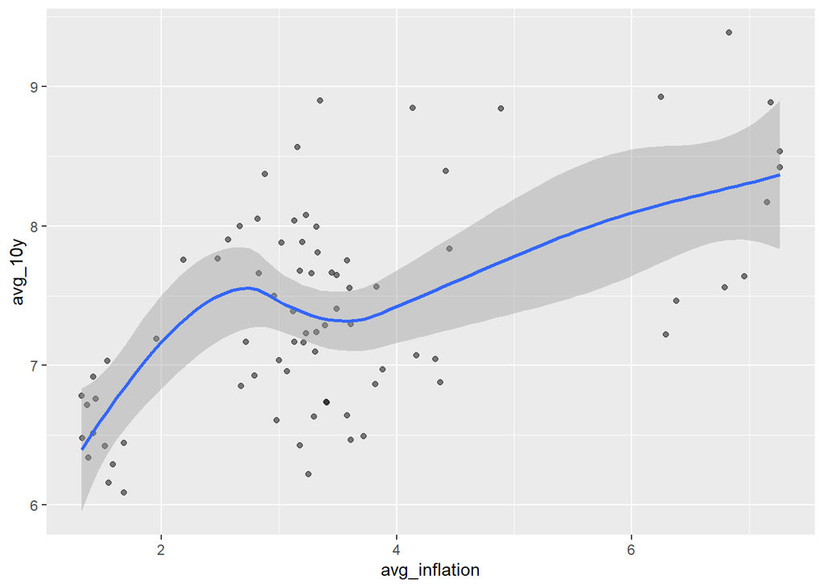

```r
# non linear relationship between yield vs inflation
yield_factors %>%
  mutate(yearmon = yearmonth(date), month = month(date), year = year(date)) %>%
  group_by(yearmon) %>%
  summarise(avg_10y = mean(domestic_10y), avg_inflation = mean(cpi_inflation)) %>%
  ggplot(aes(y = avg_10y, x = avg_inflation)) +
  geom_point(alpha =0.5)+geom_smooth()
```

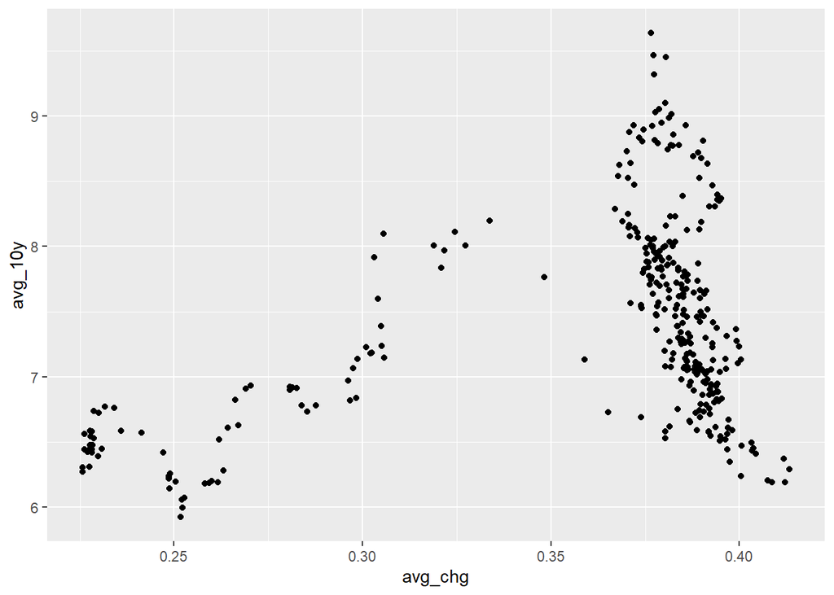

```r
# yield_factors %>%
#   mutate(yearmon = yearmonth(date), month = month(date), year = year(date)) %>%
#   group_by(yearmon) %>%
#   ggplot(aes(y = domestic_10y, x = cpi_inflation)) +
#   geom_point(alpha =0.5)

#foreign changes
## negative relationship when foreign pct > 35%, < 35% positive relationship
### due to quantitative easing of central bank 2020-2021 and mandatory purchase of domestic banks boost domestic ownership

yield_factors %>%
  mutate(week_year = yearweek(date), foreign_chg = foreign/tot_ownership) %>%
  group_by(week_year) %>%
  summarise(avg_10y = mean(domestic_10y), avg_chg = mean(foreign_chg)) %>%
  ggplot(aes(x = avg_chg, y = avg_10y)) +
  geom_point()
```

```r
# yield_factors %>%  mutate(year = year(date), con_pct = con_bank/tot_ownership, bi_pct = central_bank/tot_ownership, ins_pct = ins_pension/tot_ownership) %>%
#   # filter(year == 2019) %>%
#   select(date, foreign, central_bank, individual, mutual_fund, con_bank, islam_bank, ins_pension, others) %>%
#   gather(key = "variable", value = "value", -date) %>%
#   ggplot(aes(x = variable, y = value/1000, fill = value))+
#   geom_col()+
#   coord_flip()+
#   theme(legend.title = element_blank())


# yield_factors %>%
#   mutate(year = year(date), con_pct = con_bank/tot_ownership, bi_pct = central_bank/tot_ownership, ins_pct = ins_pension/tot_ownership) %>%
#   ggplot(aes(y = domestic_10y))+
#   geom_point(aes(x = con_pct, color = "red"))+
#   geom_point(aes(x = bi_pct))+
#   theme(legend.title = element_blank())+facet_wrap(~ year)

## others has strong positive correlation with yield
yield_factors %>%
mutate(year = year(date), mon = month(date), con_pct = con_bank/tot_ownership, bi_pct = central_bank/tot_ownership, others_pct = others/tot_ownership) %>%
  ggplot(aes(x = others, y = domestic_10y)) +
  geom_point() +
  facet_wrap(~ year)

#check ownership in auction days
# yield_factors %>%
# mutate(year = year(date), month = month(date), con_pct = scale(con_bank/tot_ownership), bi_pct = central_bank/tot_ownership, others_pct = scale(others/tot_ownership), ins_pct = scale(ins_pension/tot_ownership)) %>%
#   filter(year == 2019, month == 2) %>%
#   ggplot(aes(x = date)) +
#   geom_line(aes(y = ins_pct))+
#   geom_line(aes(y = con_pct, color = "red"))+
#   geom_point(aes(y = auction_day, color = factor(auction_day)))


# bi and con_bank is balancing each other
# since 2020, they move in the same direction
# burden sharing for pandemic
yield_factors %>%
mutate(year = year(date), con_pct = con_bank/tot_ownership, bi_pct = central_bank/tot_ownership, others_pct = scale(others/tot_ownership), ins_pct = ins_pension/tot_ownership) %>%
  ggplot(aes(x = date)) +
  geom_line(aes(y = bi_pct))+
  geom_line(aes(y = con_pct))

###CDS vs UST spread
# yield_factors %>%
#   mutate(year = year(date)) %>%
#   mutate(date= date(date), month =  month(date), spread_10 = cds_10y-domestic_10y, spread_5 = cds_5y-domestic_10y, spread_ust = domestic_10y-ust_10y) %>%
#   filter(year == 2021) %>%
#   ggplot(aes(x = date)) +
#   geom_line(aes(y = sqrt(spread_10)))+
#   geom_line(aes(y = sqrt(spread_5)), color = "red", alpha = 0.5)+
#   geom_line(aes(y = spread_ust), color = "blue")+
#    scale_x_date(labels = date_format("%m-%Y"))


### CDS vs centralbank rate spread

# yield_factors %>%
#   mutate(year = year(date)) %>%
#   mutate(date= date(date), month =  month(date), spread_10 = cds_10y-domestic_10y, spread_5 = cds_5y-domestic_10y, spread_bi = domestic_10y-rate) %>%
#   filter(year == 2021) %>%
#   ggplot(aes(x = date)) +
#   geom_line(aes(y = sqrt(spread_10)))+
#   geom_line(aes(y = sqrt(spread_5)), color = "red", alpha = 0.5)+
#   geom_line(aes(y = spread_bi), color = "blue")+
#    scale_x_date(labels = date_format("%m-%Y"))


# ust vs policy rate vs spread rate-ust
# check how differ central bank rate from UST
# yield_factors %>%
#   mutate(year = year(date)) %>%
#   mutate(date= date(date), month =  month(date), spread_10 = cds_10y-domestic_10y, spread_5 = cds_5y-domestic_10y, spread_ust = domestic_10y-ust_10y, spread_bi = domestic_10y-rate, ust_bi = rate-ust_10y) %>%
#   filter(year > 2015) %>%
#   ggplot(aes(x = date)) +
#   geom_area(aes(y = ust_bi), fill = "darkgreen", alpha = 0.5)+
#   geom_line(aes(y = rate))+
#   geom_line(aes(y = ust_10y), color = "red")+
#   # geom_line(aes(y = spread_ust))+
#   # geom_line(aes(y = spread_bi), color = "red", alpha = 0.5)+
#   scale_x_date(labels = date_format("%m-%Y"))

# yield_factors %>%
#   mutate(year = year(date)) %>%
#   mutate(date= date(date), month =  month(date), spread_10 = cds_10y-domestic_10y, spread_5 = cds_5y-domestic_10y, spread_ust = domestic_10y-ust_10y, spread_bi = domestic_10y-rate, ust_bi = rate-ust_10y) %>%
#   filter(year > 2015) %>%
#   ggplot(aes(x = spread_ust, y = domestic_10y))+
#   geom_jitter()

###spread ust vs yield in 2019 and 2021 is not strongly associated
# yield_factors %>%
#   mutate(year = year(date)) %>%
#   mutate(date= date(date), month =  month(date), spread_10 = cds_10y-domestic_10y, spread_5 = cds_5y-domestic_10y, spread_ust = domestic_10y-ust_10y, spread_bi = domestic_10y-rate, ust_bi = rate-ust_10y) %>%
#   filter(year > 2015) %>%
#   ggplot(aes(x = spread_ust, y = domestic_10y))+
#   geom_jitter()+ facet_wrap(~year)

###spread bi vs yield
# yield_factors %>%
#   mutate(year = year(date)) %>%
#   mutate(date= date(date), month =  month(date), spread_10 = cds_10y-domestic_10y, spread_5 = cds_5y-domestic_10y, spread_ust = domestic_10y-ust_10y, spread_bi = domestic_10y-rate, ust_bi = rate-ust_10y) %>%
#   filter(year > 2015) %>%
#   ggplot(aes(x = spread_bi, y = domestic_10y))+
#   geom_jitter()+
#   facet_wrap(~year)

###cds vs yield
# yield_factors %>%
#   mutate(year = year(date)) %>%
#   mutate(date= date(date), month =  month(date), spread_10 = cds_10y-domestic_10y, spread_5 = cds_5y-domestic_10y, spread_ust = domestic_10y-ust_10y, spread_bi = domestic_10y-rate, ust_bi = rate-ust_10y) %>%
#   filter(year > 2015) %>%
#   ggplot(aes(x = cds_5y, y = domestic_10y))+
#   geom_jitter()+
#   facet_wrap(~year)

# yield_factors %>%
#   mutate(year = year(date)) %>%
#   mutate(date= date(date), month =  month(date), spread_10 = cds_10y-domestic_10y, spread_5 = cds_5y-domestic_10y, spread_ust = domestic_10y-ust_10y, spread_bi = domestic_10y-rate, ust_bi = rate-ust_10y) %>%
#   filter(year > 2015) %>%
#   ggplot(aes(x = cds_10y, y = domestic_10y))+
#   geom_jitter()+
#   facet_wrap(~year)


# spread movement
# spread_2016 <- yield_factors %>%
#   mutate(year = year(date)) %>%
#   mutate(date= date(date), month =  month(date), spread_10 = domestic_10y - cds_10y/100, spread_5 = domestic_10y - cds_5y/100, spread_ust = domestic_10y-ust_10y) %>%
#   filter(year == 2016) %>%
#   ggplot(aes(x = date)) +
#   geom_line(aes(y = spread_10))+
#   geom_line(aes(y = spread_5), color = "red", alpha = 0.5)+
#   geom_line(aes(y = spread_ust), color = "blue")+
#    scale_x_date(labels = date_format("%m-%Y"))
```

[output not shown]

```r
# spread_2017 <- yield_factors %>%
#   mutate(year = year(date)) %>%
#   mutate(date= date(date), month =  month(date), spread_10 = domestic_10y - cds_10y/100, spread_5 = domestic_10y - cds_5y/100, spread_ust = domestic_10y-ust_10y) %>%
#   filter(year == 2017) %>%
#   ggplot(aes(x = date)) +
#   geom_line(aes(y = spread_10))+
#   geom_line(aes(y = spread_5), color = "red", alpha = 0.5)+
#   geom_line(aes(y = spread_ust), color = "blue")+
#    scale_x_date(labels = date_format("%m-%Y"))
#
# spread_2018 <- yield_factors %>%
#   mutate(year = year(date)) %>%
#   mutate(date= date(date), month =  month(date), spread_10 = domestic_10y - cds_10y/100, spread_5 = domestic_10y - cds_5y/100, spread_ust = domestic_10y-ust_10y) %>%
#   filter(year == 2018) %>%
#   ggplot(aes(x = date)) +
#   geom_line(aes(y = spread_10))+
#   geom_line(aes(y = spread_5), color = "red", alpha = 0.5)+
#   geom_line(aes(y = spread_ust), color = "blue")+
#    scale_x_date(labels = date_format("%m-%Y"))
#
# spread_2019 <- yield_factors %>%
#   mutate(year = year(date)) %>%
#   mutate(date= date(date), month =  month(date), spread_10 = domestic_10y - cds_10y/100, spread_5 = domestic_10y - cds_5y/100, spread_ust = domestic_10y-ust_10y) %>%
#   filter(year == 2019) %>%
#   ggplot(aes(x = date)) +
#   geom_line(aes(y = spread_10))+
#   geom_line(aes(y = spread_5), color = "red", alpha = 0.5)+
#   geom_line(aes(y = spread_ust), color = "blue")+
#    scale_x_date(labels = date_format("%m-%Y"))
#
# spread_2020 <- yield_factors %>%
#   mutate(year = year(date)) %>%
#   mutate(date= date(date), month =  month(date), spread_10 = domestic_10y - cds_10y/100, spread_5 = domestic_10y - cds_5y/100, spread_ust = domestic_10y-ust_10y) %>%
#   filter(year == 2020) %>%
#   ggplot(aes(x = date)) +
#   geom_line(aes(y = spread_10))+
#   geom_line(aes(y = spread_5), color = "red", alpha = 0.5)+
#   geom_line(aes(y = spread_ust), color = "blue")+
#    scale_x_date(labels = date_format("%m-%Y"))
#
# spread_2021 <- yield_factors %>%
#   mutate(year = year(date)) %>%
#   mutate(date= date(date), month =  month(date), spread_10 = domestic_10y - cds_10y/100, spread_5 = domestic_10y - cds_5y/100, spread_ust = domestic_10y-ust_10y) %>%
#   filter(year == 2021) %>%
#   ggplot(aes(x = date)) +
#   geom_line(aes(y = spread_10))+
#   geom_line(aes(y = spread_5), color = "red", alpha = 0.5)+
#   geom_line(aes(y = spread_ust), color = "blue")+
#   scale_x_date(labels = date_format("%m-%Y"))
#
#
# plot_spread <- patchwork::wrap_plots(spread_2016, spread_2017, spread_2018, spread_2019, spread_2020, spread_2021, ncol = 3)
###spread mostly below cds, except in 2016 and 2020 after pandemic in march

yield_factors %>%
  mutate(date= date(date), year = year(date), bi_pct = central_bank/tot_ownership, con_pct = con_bank/tot_ownership, islam_pct = islam_bank/tot_ownership, ind_pct = individual/tot_ownership, foreign_pct = foreign/tot_ownership) %>%
  ggplot(aes(y = domestic_10y)) +
  geom_point(aes(x = foreign_pct)) +
  facet_wrap(~ year)

## insurance and pension fund strongly positive correlation
yield_factors %>%
  mutate(date= date(date), year = year(date), bi_pct = central_bank/tot_ownership, con_pct = con_bank/tot_ownership, islam_pct = islam_bank/tot_ownership, ind_pct = individual/tot_ownership, ins_pct = ins_pension/tot_ownership) %>%
  ggplot(aes(y = domestic_10y)) +
  geom_point(aes(x = ins_pct)) +
  facet_wrap(~ year)

yield_factors %>%
  mutate(date= date(date), year = year(date), bi_pct = central_bank/tot_ownership, con_pct = con_bank/tot_ownership, islam_pct = islam_bank/tot_ownership, ind_pct = individual/tot_ownership, ins_pct = ins_pension/tot_ownership, other_pct = others/tot_ownership) %>%
  ggplot(aes(y = domestic_10y)) +
  geom_point(aes(x = other_pct))+
  facet_wrap(~ year)

yield_factors %>%
  mutate(date= date(date), year = year(date), bi_pct = central_bank/tot_ownership, con_pct = con_bank/tot_ownership, islam_pct = islam_bank/tot_ownership, ind_pct = individual/tot_ownership, ins_pct = ins_pension/tot_ownership, other_pct = others/tot_ownership, mutual_pct = mutual_fund/tot_ownership) %>%
  ggplot(aes(y = domestic_10y)) +
  geom_point(aes(x = mutual_fund))+
  facet_wrap(~ year)

## check ggscatmat
# yield_factors %>%
#   mutate(year = year(date)) %>%
#   filter(year == 2020) %>%
#     select(domestic_10y, cds_5y, ust_10y, central_bank, exchange_mid) %>%
# GGally::ggscatmat()

### auction vs non_auc days
average_2016 <- yield_factors %>% mutate(year = year(date)) %>%  filter(year == 2016) %>%
  mutate(month = month(date)) %>%
  group_by(month) %>%  summarise(mean = mean(domestic_10y))

average_2017 <- yield_factors %>% filter(year == 2017) %>%
  mutate(month = month(date)) %>%
  group_by(month) %>%  summarise(mean = mean(domestic_10y))

average_2018 <- yield_factors %>% filter(year == 2018) %>%
  mutate(month = month(date)) %>%
  group_by(month) %>%  summarise(mean = mean(domestic_10y))

average_2019 <- yield_factors %>% filter(year == 2019) %>%
  mutate(month = month(date)) %>%
  group_by(month) %>%  summarise(mean = mean(domestic_10y))

average_2020 <- yield_factors %>% filter(year == 2020) %>%
  mutate(month = month(date)) %>%
  group_by(month) %>%  summarise(mean = mean(domestic_10y))

average_2021 <- yield_factors %>% filter(year == 2021) %>%
  mutate(month = month(date)) %>%
  group_by(month) %>%  summarise(mean = mean(domestic_10y))
#
yield_factors  %>%
  mutate(month = month(date), year = year(date)) %>%
  filter(year == 2018) %>%
  group_by(month) %>%
ggplot(aes(x = factor(day(date)), y = domestic_10y, color = factor(auction_day), alpha = 0.1))+
  geom_point()+scale_x_discrete(breaks = seq(1, 31, 4))+
  geom_hline(data = average_2018, aes(yintercept = mean), alpha = 0.5, linetype = "dashed")+
  facet_wrap(~month)+theme_bw()+xlab("Date")+ylab("Yield 10y")

######comparing yield in auction day and non-auction day
# slightly higher in Feb and Dec
yield_factors  %>%
  mutate(month = month(date, label = TRUE), year = year(date)) %>%
  select(domestic_10y, auction_day, month, year) %>% drop_na() %>%
  filter(year > 2015) %>%
ggplot(aes(y= domestic_10y, group = auction_day, color = factor(auction_day)))+
  geom_boxplot()+
  facet_wrap(~year)
```

[output not shown]

```r
yield_factors  %>%
  mutate(month = month(date, label = TRUE), year = year(date)) %>%
  filter(year != 2015) %>%
ggplot(aes(y= domestic_10y, group = auction_day, color = factor(auction_day)))+
  geom_boxplot()+
  facet_wrap(~month)

#
# yield_factors %>% filter(year == 2018) %>%
#   mutate(month = month(date)) %>%
#   group_by(month) %>%
# ggplot(aes(x = factor(day(date)), y = domestic_10y, color = factor(auction_day), alpha = 0.1))+
#   geom_point()+scale_x_discrete(breaks = seq(1, 31, 4))+
#   geom_hline(data = average_2018, aes(yintercept = mean), alpha = 0.5)+
#   facet_wrap(~month)
#
# yield_factors %>% filter(year == 2019) %>%
#   mutate(month = month(date)) %>%
#   group_by(month) %>%
# ggplot(aes(x = factor(day(date)), y = domestic_10y, color = factor(auction_day), alpha = 0.1))+
#   geom_point()+scale_x_discrete(breaks = seq(1, 31, 4))+
#   geom_hline(data = average_2019, aes(yintercept = mean), alpha = 0.5)+
#   facet_wrap(~month)
#
# yield_factors %>% filter(year == 2020) %>%
#   mutate(month = month(date)) %>%
#   group_by(month) %>%
# ggplot(aes(x = factor(day(date)), y = domestic_10y, color = factor(auction_day), alpha = 0.1))+
#   geom_point()+scale_x_discrete(breaks = seq(1, 31, 4))+
#   geom_hline(data = average_2020, aes(yintercept = mean), alpha = 0.5)+
#   facet_wrap(~month)
#
# yield_factors %>% filter(year == 2021) %>%
#   mutate(month = month(date)) %>%
#   group_by(month) %>%
# ggplot(aes(x = factor(day(date)), y = domestic_10y, color = auction_day, alpha = 0.1))+
#   geom_point()+scale_x_discrete(breaks = seq(1, 31, 4))+
#   geom_hline(data = average_2021, aes(yintercept = mean), alpha = 0.5)+
#   facet_wrap(~month)

# cek <- yield_factors %>%
#   group_by(auction_day) %>% select(!pre_auction)
#   # mutate(domestic_10y = as.numeric(domestic_10y)) %>%

# yield_factors %>% mutate(year = year(date)) %>%
#   filter(year == 2016) %>%
#   mutate(month = month(date)) %>%
#   ggplot(aes(y = domestic_10y, color = auction_day)) +
#   geom_boxplot()+facet_wrap(~month)

# cek %>% filter(year == 2017) %>%
#   mutate(month = month(date)) %>%
#   ggplot(aes(y = domestic_10y, color = auction_day)) +
#   geom_boxplot()+facet_wrap(~month)
#
# cek %>% filter(year == 2018) %>%
#   mutate(month = month(date), date = date(date)) %>%
#   ggplot(aes(y = domestic_10y, x= factor(date), color = auction_day)) +
#   geom_point()+facet_wrap(~month)
#
# cek %>% filter(year == 2020) %>%
#   mutate(month = month(date)) %>%
#   ggplot(aes(y = domestic_10y, color = auction_day)) +
#   geom_boxplot()+facet_wrap(~month)+theme(legend.position = "bottom")



# yield distribution in each year
# 2018 yield move from low in early year to high in late period of year
# different direction compared to other years

# 2021 yield tend to be restrained in the middle
# yield_factors %>% mutate(year = year(date)) %>% filter(year == 2021) %>%
#   mutate(month = month(date)) %>%
#   ggplot(aes(x = domestic_10y, color = auction_day), group = auction_day) +
#   geom_density()+
#                facet_wrap(~ month)

###prepare variable for model
data_model <- yield_factors %>% mutate(year = year(date), month = factor(month(date))) %>%
  mutate(foreign_pct = foreign/tot_ownership) %>%
  mutate(date= date(date), year = factor(year), month =  factor(month(date)),
          auction_day = factor(auction_day)) %>%
  select(date,  year, month, domestic_10y, cds_5y, ust_10y, rate, foreign_pct, vix, exchange_mid, auction_day, cpi_inflation) %>% drop_na()


# model <- lm(formula = domestic_10y ~ cds_5y + ust_10y + rate:year + foreign + ins_pension + foreign:year + ins_pension:year + auction_day:month,
#  data = data_model)


model <- lm(formula = domestic_10y ~ cds_5y + ust_10y + rate + foreign_pct + I(vix^2) + exchange_mid + auction_day,
            data = data_model)

summary(model)
tidy(model)

summary(data_model)

# highest vix in early pandemic 2020-03-16
# MArch 2 2020 is the first case of covid
data_model %>% filter (vix == 82.69)


# best <- drop1(model, test = "F")
# summary(best)

library(broom)
aug <- broom::augment(model, data = data_model %>% filter(year != 2015) %>% drop_na())

aug %>%
  ggplot(aes(x = .fitted, y = .resid))+
  geom_point()

aug %>%
  ggplot(aes(x = .cooksd, y = .hat))+
  geom_point()

# aug %>%
#   ggplot(aes(x = .cooksd, y = .hat))+
#   geom_point()

outlier <- aug %>% filter(.cooksd > 0.05)

#not in
`%notin%` <- Negate(`%in%`)

data_model %>% filter(date %in% outlier$date)

####remove extreme outliers
data_model2 <- data_model %>% filter(date %notin% outlier$date)

# model <-  lm(formula = domestic_10y ~ cds_5y + ust_10y + rate + foreign:year + I(vix^2) + exchange_mid + auction_day:month, data = data_model2)


# model <- lm(formula = domestic_10y ~ cds_5y + ust_10y + rate + foreign:year + I(vix^2) + cpi_inflation + exchange_mid + auction_day:year,
#             data = data_model)

summary(model)
tidy(model)

aug <- broom::augment(model, data = data_model2 %>% filter(year != 2015) %>% drop_na())

aug %>%
  ggplot(aes(x = .fitted, y = .resid))+
  geom_point()

aug %>%
  ggplot(aes(x = .cooksd, y = .hat))+
  geom_point()

#check multicol
#explain GVIF variable
car::vif(model)

# reduce to "best fit" model with

summary(model)
# model_best <- step(model, trace = FALSE)
# summary(model_best)

#diagnose model
ggnostic(model_best)
```

[output not shown]

To mention, 2017 is the year when Indonesia got investment grade rating from S&P, following FITCH and Moody’s in previous years. It means that broader category of foreign investment entities (i.e. pension funds and insurance) can enter the country’s market since Indonesia’s rating has fulfilled their criteria of investment (yunianto, 2018).

We may assume that the anomaly in 2020 and 2021 are due to Covid19 pandemic that occurred since early 2020. The government is increasing its funding to sustain the economy. The decrease in foreign portion could be because foreigners sell their bonds more than their buying (net sell), or another reason is because their portion is deluged by domestic participants (i.e. central bank), thus we will track the pattern of domestic ownership in these years to check our assumption.

```r
#scattermatrix
# yield_factors %>%
#   filter(year > 2019) %>%
# GGally::ggscatmat(columns = c(2,3,4,5))

# yield_factors %>%
#   filter(year > 2019) %>%
#   mutate(bi_pct = central_bank/tot_ownership, indv_pct = individual/tot_ownership, insp_pct = ins_pension/tot_ownership, mut_pct = mutual_fund/tot_ownership, sec_pct = securities_company/tot_ownership, conv_pct = con_bank/tot_ownership, isl_pct = islam_bank/tot_ownership) %>%
#   select(domestic_10y, foreign_pct, bi_pct, indv_pct, insp_pct, mut_pct, sec_pct, conv_pct, isl_pct) %>%
# GGally::ggscatmat()

# yield_factors %>%
#   filter(year > 2018) %>%
# GGally::ggscatmat(columns = c(5, 13, 14, 15, 16, 17, 18, 19))

model <- lm(domestic_10y ~ cds_5y + ust_10y + foreign + rate + con_bank, data = yield_factors)

# reduce to "best fit" model with
model_best <- step(model, trace = FALSE)
summary(model)
```

```
##
## Call:
## lm(formula = domestic_10y ~ cds_5y + ust_10y + foreign + rate +
##     con_bank, data = yield_factors)
##
## Residuals:
##      Min       1Q   Median       3Q      Max
## -1.44899 -0.15056 -0.03247  0.17758  0.75192
##
## Coefficients:
##              Estimate Std. Error t value Pr(>|t|)
## (Intercept) 1.477e+00  9.800e-02   15.07   <2e-16 ***
## cds_5y      1.171e-02  2.492e-04   47.01   <2e-16 ***
## ust_10y     3.056e-01  1.252e-02   24.40   <2e-16 ***
## foreign     1.082e-03  7.989e-05   13.55   <2e-16 ***
## rate        4.955e-01  1.382e-02   35.85   <2e-16 ***
## con_bank    6.016e-04  3.615e-05   16.64   <2e-16 ***
## ---
## Signif. codes:  0 '***' 0.001 '**' 0.01 '*' 0.05 '.' 0.1 ' ' 1
##
## Residual standard error: 0.2404 on 1368 degrees of freedom
##   (338 observations deleted due to missingness)
## Multiple R-squared:  0.8461, Adjusted R-squared:  0.8456
## F-statistic:  1504 on 5 and 1368 DF,  p-value: < 2.2e-16
```

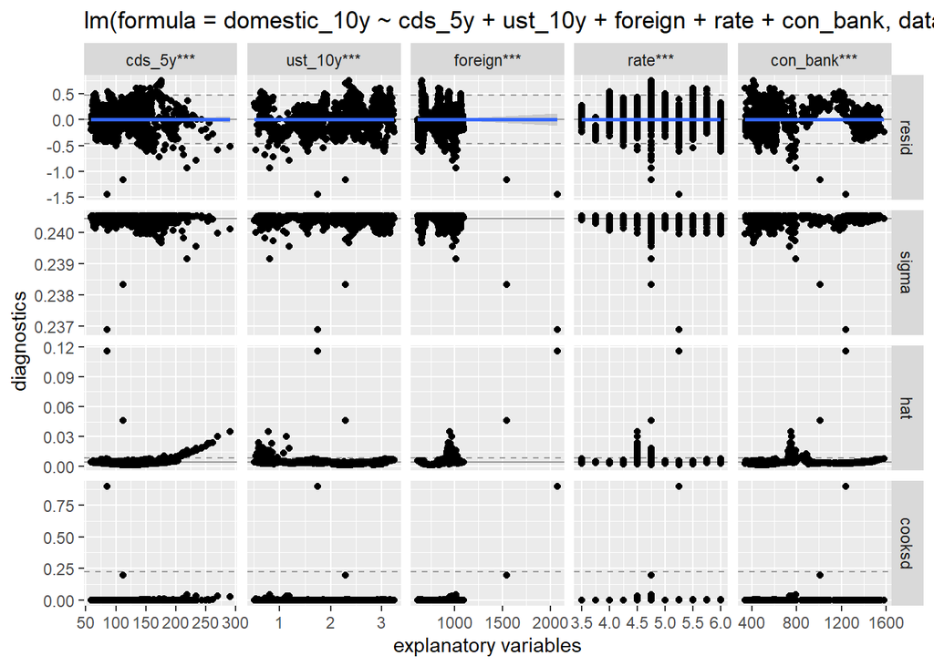

```r
#diagnose model
ggnostic(model)
```

## Policy Rate

```r
# yield_factors %>%
#   na.omit() %>%
#   mutate(year = year(date)) %>%
#    filter(year != 2015) %>%
#   select(date, domestic_10y, rate, foreign, central_bank) %>%
#   gather(key = "variable", value = "value", -date) %>%
#   ggplot(aes(x = date, y = log(value)))+
#   geom_smooth(aes(color = variable))+theme_minimal()

## ownership pct
yield_factors %>%
  na.omit() %>%
  mutate(date= date(date), year = year(date), bi_pct = central_bank/tot_ownership, con_pct = con_bank/tot_ownership, islam_pct = islam_bank/tot_ownership, ind_pct = individual/tot_ownership, other_pct = others/tot_ownership, mutual_pct = mutual_fund/tot_ownership, ins_pct = ins_pension/tot_ownership, foreign_pct = foreign/tot_ownership) %>%
   filter(year != 2015) %>%
  select(date, foreign_pct, bi_pct, con_pct, islam_pct, ind_pct, other_pct, mutual_pct, ins_pct) %>%
  gather(key = "variable", value = "value", -date) %>%
  ggplot(aes(x = date, y = value))+
  geom_area(aes(fill = variable), alpha = 0.7)+
  theme_classic()

####Others = securities, corporations, and foundations.

# spread pol-rate vs yield
# 2020 spread range between policy rate and yield is quite dispersed
# 2021 spread range is the narrowest
#
yield_factors %>%
  na.omit() %>%
  mutate(year = year(date), spread = abs(domestic_10y-rate)) %>%
  filter(year > 2015) %>%
  select(date, year, spread, domestic_10y, rate) %>%
  ggplot(aes(y = spread))+
  geom_boxplot()+
  facet_wrap(~year)
```

[output not shown]